# San Francisco International Airport Passenger Traffic

Jacques Sham & Charles Siu

## Part 1: Executive Summary

San Francisco is the Pacific gateway to the United States. Commuters travel in and out of the city, and a great percentage of those is by air, through the San Francisco International Airport (SFO). Maintenance for SFO accounts for a considerable amount in tax expenditure. We would like to investigate whether tax revenue is spent wisely by examining the passenger traffic of SFO. DataSF, San Francisco’s official open data portal, maintains a dataset on the passenger count for every airline that operates at SFO. The dataset contains more than 17,000 entries between 2005 and 2017. Each entry is a flight activity that contains the name of the airline, the destination or origin region of the flight, as well as the passenger count. We analyzed the dataset and discovered that, the passenger traffic at SFO was growing at a steady rate, demand for international travel was increasing among low cost carriers, and United Airlines is the largest operator at SFO. We believe passenger traffic determine the effective use of tax revenue in SFO. Meanwhile, understanding passenger traffic pattern helps decision-making on investment. This analysis allows San Francisco taxpayers to understand how tax is spent on air travel infrastructure, and for airport authorities to propose investments for airport expansion.

## Part 2: Introduction to the Data

### I. Overview

San Francisco is the 13th largest city in the United States and is the Pacific Gateway to the nation. The city’s airport SFO, accounts for the majority of air traffic in and out of the SF Bay Area. SFO has been in operation since 1927, with its first international service started in 1946. The airport is the 2nd busiest airport in California, the 7th busiest airport in the United States, and the 23rd busiest airport in the world. SFO has received numerous awards from various air travel rating agencies, such as the 3rd Best Airport in North America in 2012 and 3rd Best Airport Worldwide in 2014 from SkyTrax. There are 3 domestic terminals and 1 international terminal to accommodate the massive flow of passengers travelling to different parts of the United States and the world.

The dataset we sourced from DataSF includes destination, origin, airlines, terminals, and passenger count between July 2005 and December 2017. The dataset contains `17,959` rows and `12` columns. Here is the link to the dataset: https://data.sfgov.org/Transportation/Air-Traffic-Passenger-Statistics/rkru-6vcg

The report is going to investigate the following facts about SFO:

1. Average monthly passengers traffic between 2006 and 2017
2. Passengers traffic by destination/origin regions
3. Overview on passengers traffic by domestic airlines
4. Passengers traffic traveled by Low Cost Carrier
5. Passengers traffic in airport terminals
6. Passengers traffic on 1 selected domestic carrier

Before we analyze the dataset, we have to clean the data and double check its accuracy.

We first parsed the unreadable `Activity Period` into a Date object and split it into Month and Year. We also dropped all entries from 2005 since the dataset only covers part of the year. We combined `Central America` and `South America` into `Latin America` since both regions are insignificant to be analyzed on their own.

In addition, we have renamed the column names of the dataset and converted the data structure of some columns for the convenience of the analysis. Here is the explanation of each column:

- **airline** [character]: Airline name
- **code** [character]: IATA code for the airline
- **isDomestic** [logical]: `T` if flight is domestic; `F` if flight is international. Flights from/to Canada counts as International
- **region** [character]: Geographic region including `US`, `Canada`, `Mexico`, `Latin America`, `Europe`, `Middle East`, `Asia`, and `Australia / Oceania`
- **type** [character]: Activity type; `Deplaned` means arrival, `Enplaned` means departure, `Thru / Transit` means flight transit at SFO
- **category** [factor]: Airline price type; `Low Fare` is Low cost carrier, `Full Service` otherwise
- **terminal** [factor]: SFO terminal
- **area** [character]: Area within SFO terminal
- **pax** [int]: Passenger count of given row
- **month** [factor]: The `month` of the airline operates
- **year** [double]: The `year` of the airline operates

We also have to verify the accuracy of the data. Below are the steps we took to fix the dataset:

**Step 1: Standardize `United Airlines`**

`United Airlines` merged with `Continent Airlines` in 2013 that some data from `United Airlines` are written in `United Airlines - Pre 07/01/2013` that we have to convert this to `United Airlines` as we can tell those flights were `United Airlines`’ operation.

**Step 2: Standardize `Emirates`**

Some of `Emirates` data were recorded followed with a space. It looks like a typing error but it creates error when analyzing the data, so that I have to standardize all `Emirates` related data.

**Step 3: Re-identify the category**

There are a lot of `full service carrier` misidentified as `low cost carrier`, and vice versa. The international official aviation organization, International Civil Aviation Organization (ICAO), has an official definition on `low cost carrier` and provides a list of `low cost carrier`. We checked the airlines in the dataset and converted some of the wrongly identified airlines according to the list from ICAO. For example, the dataset wrongly recorded `Wow Air` as `full service carrier` but the airline is identified as `low cost carrier` by ICAO.

This is the list of low cost carrier: https://www.icao.int/sustainability/Documents/LCC-List.pdf

## Part 3: Exploratory Analysis

### I. Overview on Passenger traffic in SFO

#### Overall Passenger Traffic between 2006 and 2017

SFO is a busy airport and is a transpacific gateway on the West Coast of the United States, and the passenger traffic is heavy. There were `55,823,712` passengers traveled through SFO in 2017, compared to `33,332,970` in 2006. The average annual passenger growth in the period is `4.82%`. It will take `15` years after 2006 for SFO to double the passenger traffic, in `2021`.

#### Average Passenger Traffic between 2006 and 2017

The airline industry is a season-sensitive industry, meaning that the passenger traffic varies by seasons. Generally, summer and Christmas holidays are two major peak seasons in the airline industry. Therefore, we expect SFO to experience higher passenger traffic in those periods.

Below is the bar chart of monthly average total passenger count of SFO between 2006 and 2017.

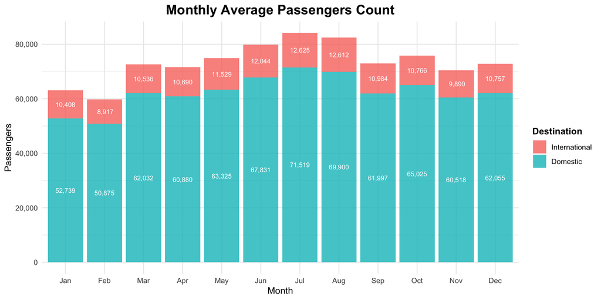

```r
data %>%
  group_by(isDomestic, month) %>%
  summarise(avg_pax = round(mean(pax), digit = 0)) %>%
  ggplot(aes(x = factor(month, labels = month.abb), y = avg_pax, fill = isDomestic)) +
  geom_bar(stat = "identity", alpha = 0.8) +
  theme_minimal() +
  scale_y_continuous(labels = comma) +
  scale_fill_discrete(name = "Destination", label = c("International","Domestic")) +
  labs(x = "Month", y = "Passengers") +
  ggtitle("Monthly Average Passengers Count") +
  geom_text(aes(label = format(avg_pax, big.mark = ",")), size = 2.75,
            position = position_stack(vjust = 0.5), colour = "white") +
  format_title +
  format_legend_title
```

### II. Destination

And the map below shows the passengers count on other regions outside North America between 2006 and 2017.

```r
# Load the world map and cities
world <- map_data("world")
cities <- world.cities
# Retrieve the information of SF
sf <- world.cities %>%
  filter(name == "San Francisco" & country.etc == "USA")
# Derive the cities and corresponding regions
cities %<>%
  filter(
    (name == "Adelaide" & country.etc == "Australia") | (name == "La Paz" & country.etc == "Bolivia") |
    (name %in% c("Saint Louis", "La Ronge","Riyadh", "Mexico City", "Shenzhen", "Ostrava"))) %>%
  mutate(region =
           ifelse(name == "Adelaide", "Australia / Oceania", ifelse(name == "Saint Louis", "US",
           ifelse(name == "La Ronge", "Canada", ifelse(name == "La Paz", "Latin America",
           ifelse(name == "Riyadh", "Middle East", ifelse(name == "Mexico City", "Mexico",
           ifelse(name == "Shenzhen", "Asia", ifelse(name == "Ostrava", "Europe", NA))))))))
  ) %>%
  full_join(y = data %>%
              mutate(region = as.character(region)) %>%
              group_by(region, type) %>%
              summarize(pax = sum(pax)), by = "region") %>%
  mutate(
    origin.lat = ifelse(type == "Enplaned", sf$lat, lat),
    origin.long = ifelse(type == "Enplaned", sf$long, long),
    dest.lat = ifelse(type == "Enplaned", lat, sf$lat),
    dest.long = ifelse(type == "Enplaned", long, sf$long)
  ) %>%
  filter(type != "Thru / Transit")
cities_na <- cities %>% filter(region %in% c("US", "Canada", "Mexico"))
cities_intl <- cities %>% filter(!(region %in% c("US", "Canada", "Mexico")))
```

```r
# Geom objects for drawing static objects
draw_sf_point <- geom_point(x = sf$long, y = sf$lat, color = "red", size = 3)
draw_intl_sf_label <- geom_text(aes(x = sf$long, y = sf$lat, label = "SFO"),
                           hjust = 1, nudge_x = -5, color = "red", size = 3)
draw_color_legend <- scale_color_discrete(name = "Activity Type",
                                          labels = c("Arriving SFO", "Departing SFO"))
draw_size_legend <- scale_size_continuous(trans = "log10", guide = F)

# Functions for drawing curves, points and labels
draw_flight_curve <- function(d) {
  geom_curve(data = d %>% filter(type %in% c("Deplaned", "Enplaned")),
                           aes(x = origin.long, y = origin.lat, xend = dest.long, yend = dest.lat,
                               color = type, size = pax), curvature = 0.5, lineend = "round",
                           alpha = 0.75, arrow = arrow(length = unit(0.025, "npc")))
}
draw_city_points <- function(d) {
  return (geom_point(data = d, aes(x = long, y = lat), color = "black", size = 3))
}

draw_intl_city_labels <- geom_text(data = cities_intl,
                              aes(x = long, y = lat, label = region),
                              hjust = 0, nudge_x = 3.5, nudge_y = -1,
                              color = "black", size = 3)
draw_intl_enplaned_labels <- geom_label(data = cities_intl %>% filter(type == ("Enplaned")),
      aes(x = long, y = lat, label = format(pax, big.mark = ","), color = type),
      hjust = 0, nudge_x = 3.5, nudge_y = -7, size = 3, show.legend = F)
draw_intl_deplaned_labels <-geom_label(data = cities_intl %>% filter(type == ("Deplaned")),
      aes(x = long, y = lat - 4, label = format(pax, big.mark = ","), color = type),
      hjust = 0, nudge_x = 3.5, nudge_y = -9.5, size = 3, show.legend = F)

format_theme <- theme(
  axis.text = element_blank(),
  axis.line = element_blank(),
  axis.ticks = element_blank(),
  panel.border = element_blank(),
  panel.grid = element_blank(),
  axis.title = element_blank(),
  legend.position = "bottom",
  legend.background = element_rect(fill = "gray90", size = 0),
  legend.title = element_text(face = "bold")
  )
```

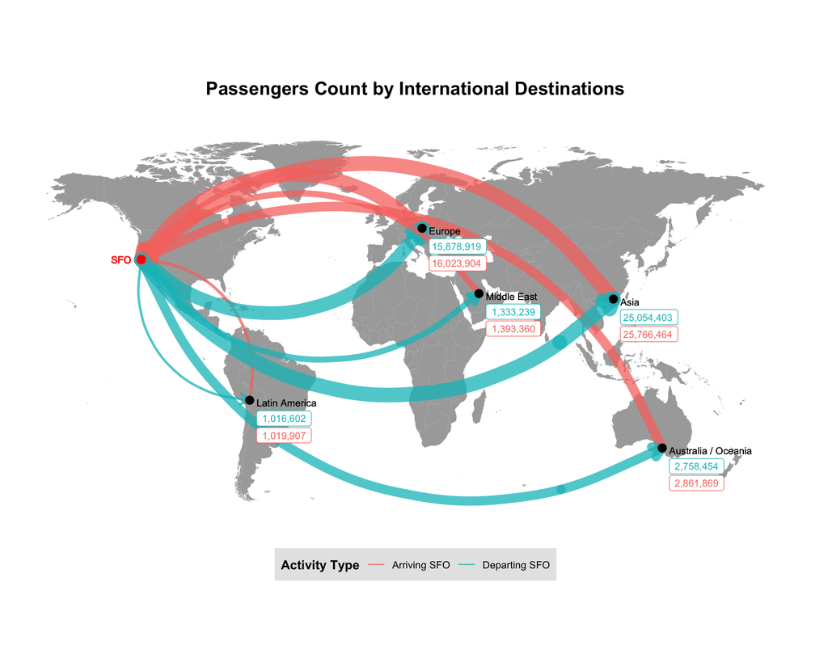

```r
world %>%
  filter(region != "Antarctica") %>%
  ggplot() +
  geom_polygon(aes(x = long, y = lat, group = group), fill = "darkgray") +
  draw_flight_curve(cities_intl) +
  draw_city_points(cities_intl) +
  draw_intl_city_labels +
  draw_sf_point +
  draw_intl_sf_label +
  draw_intl_enplaned_labels +
  draw_intl_deplaned_labels +
  coord_fixed(1.3) +
  theme_minimal() +
  draw_color_legend +
  draw_size_legend +
  scale_x_continuous(limits = c(-170, 200)) +
  scale_y_continuous(limits = c(-60, 90)) +
  ggtitle("Passengers Count by International Destinations") +
  format_theme +
  format_title
```

```r
region_pax <- data %>% group_by(region) %>% summarise(sumpax = sum(pax)) %>% arrange(desc(sumpax))
```

The map shows that `Asia` is the continent of the most passengers flying from or to after the United States, with `51,040,819` passengers, followed by `Europe`. Surprisingly there are less passengers coming from or going to `Canada` and `Mexico` than they coming from or going to `Asia` or `Europe`, `16,211,371` and `9,983,551` passengers, respectively, and the passenger traffic coming from or going to `Latin America` is very little, with `2,036,509`.

### III. Domestic Carriers Overview

```r
# Filter the top 5 airlines by domestic passenger count
top5_dom_list <- data %>%
  filter(isDomestic) %>%
  group_by(airline) %>%
  summarise(total_pax = sum(pax)) %>%
  top_n(5, total_pax) %>%
  arrange(total_pax) %>%
  select(-total_pax)
# Combine and compute the other airlines
other_dom_airline <- data %>%
  filter(!(airline %in% top5_dom_list$airline)) %>%
  group_by(year) %>%
  summarise(sum = sum(pax)) %>%
  mutate(airline = "Other Airlines") %>%
  select(airline, year, sum)
```

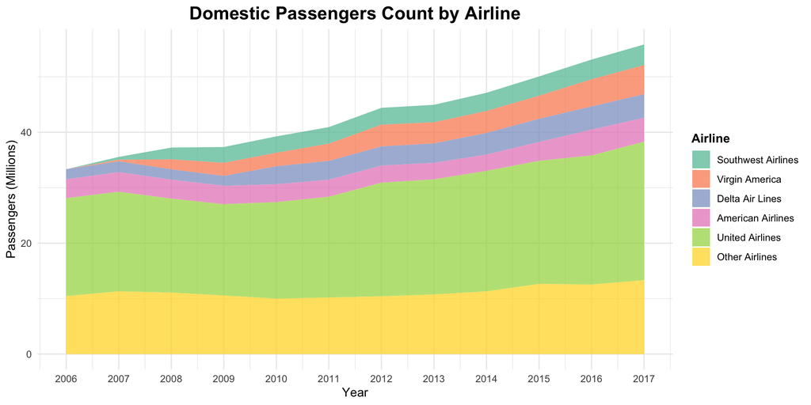

```r
data %>%
  group_by(airline, year) %>%
  summarize(sum = sum(pax)) %>%
  right_join(top5_dom_list, by = "airline") %>%
  ungroup() %>%
  rbind(other_dom_airline) %>%
  rbind(data %>%
          group_by(airline) %>%
          right_join(top5_dom_list, by = "airline") %>%
          summarize(year = min(year) - 1) %>%
          filter(year == min(data$year)) %>%
          mutate(sum = 0)) %>%
  mutate(airline = factor(airline,
      levels = rbind(top5_dom_list, "Other Airlines")$airline)) %>%
  ggplot() +
  geom_area(aes(x = year, y = sum / million, fill = airline), alpha = 0.75) +
  scale_x_continuous(name = "Year",
          breaks = seq(min(data$year), max(data$year), by = 1)) +
  scale_y_continuous(name = "Passengers (Millions)") +
  scale_fill_brewer(name = "Airline", palette = "Set2") +
  theme_minimal() +
  ggtitle("Domestic Passengers Count by Airline") +
  format_title +
  format_legend_title
```

The chart shows that a large portion of SFO travelers are traveling by United Airlines, while SFO is one of the hub of United Airlines in the West Coast. Southwest Airlines, Virgin America (Recently Merged with `Alaska Airlines` in 2017), Delta Air Lines, American Airlines are the other top 5 major carrier in SFO in passenger count. A large portion of travelers in SFO travel with those airlines, `85.43%` of all domestic travelers traveled with those airlines between 2006 and 2017.

### III. Low Cost Carrier vs Full Service Carrier

Due to the advances in aviation technology, the cost of air travel significantly decreased in the last 40 years. Low cost carriers provide low cost traveling by significantly reducing ticket price to attract passengers. Meanwhile, in order to compensate the loss in revenue, `low cost carriers` have made meals, seating comfort, in-flight entertainment, and seating priority extra cost options. Conversely, airlines that provide decent meals, in-flight entertainment, and offer comfortable seats and seating priority are called `full service carrier`. For travelers without much demand for full service, traveling with low cost carriers is a good alternative. `Southwest Airlines` is one of the successful stories and is a low cost carrier giant in the United States. In 2016, Iceland-based low cost carrier, `Wow Air`, began scheduled service from Reykjavik, Iceland to SFO, which made it the first low cost carrier to operate regular scheduled service to SFO outside of the North America.

In 2017, `6,317,794` passengers traveled via SFO by low cost carriers, which makes up about `11.32%` of the total passengers traffic.

There was no international low cost carrier provide regular scheduled service to SFO prior to 2016. `WestJet Airlines` and `XL Airways France` were the only international low cost carriers operating seasonal routes to and from SFO. In 2016, `Wow Air` began scheduled service from Reykjavik, Iceland. Below is the bar chart on the passengers count on international low cost carriers.

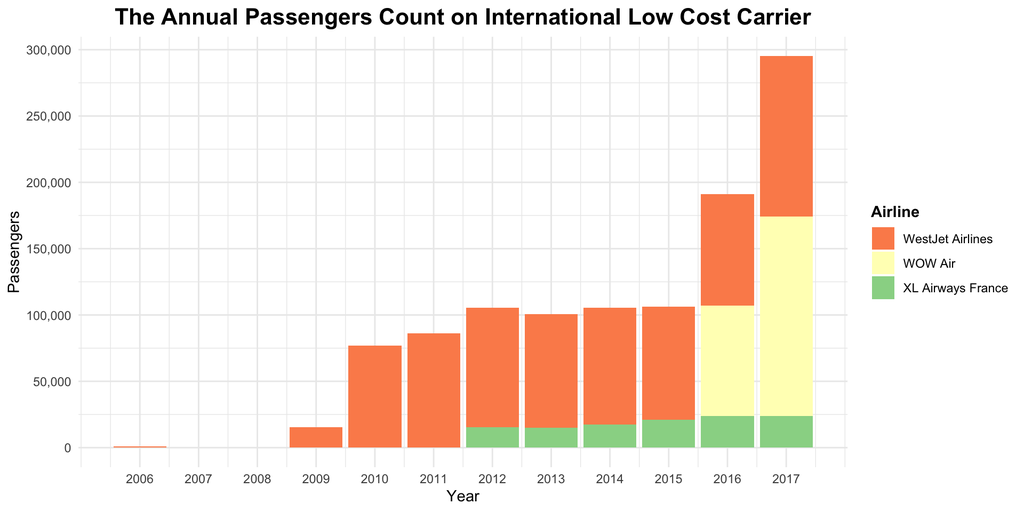

```r
intl_lcc_plot %>% ggplot(aes(x = year, y = sumpax, fill = airline)) +
  scale_fill_brewer(name = "Airline", palette = "Spectral") +
  geom_bar(stat = "identity") +
  scale_x_continuous(name = "Year",
        breaks = seq(min(data$year), max(data$year), by = 1)) +
  scale_y_continuous(name = "Passengers", breaks = seq(0, 500000, by = 50000), labels = comma)+
  ggtitle("The Annual Passengers Count on International Low Cost Carrier")+
  theme_minimal() +
  format_title +
  format_legend_title
```

The passengers traffic almost doubled when `Wow Air` between 2016 and 2017. During the first year it began service to SFO, the growth rate in passenger traffic was 81.2%. However, `Wow Air`‘s service to SFO is new, we expect the growth rate would smooth out to single digit by 2019 if we observe the pattern from `Southwest Airlines`’ first 3 years of service at SFO.

Although many travelers do not travel with low cost carriers, there are increasingly more passengers travel with `Southwest Airlines` and `Wow Air`. Therefore, we expect the portion of passengers traveled with low cost carrier increase.

### IV. Terminal Traffic

There are 4 terminals in SFO along with 115 gates: Terminal 1 (T1), Terminal 2 (T2), Terminal 3 (T3), and International Terminal (IT). T1, T2, and T3 are designed to handle domestic and precleared flights from Canada, and IT are to handle international flights.

Below is the tree map on domestic passenger traffic by terminal in 2017.

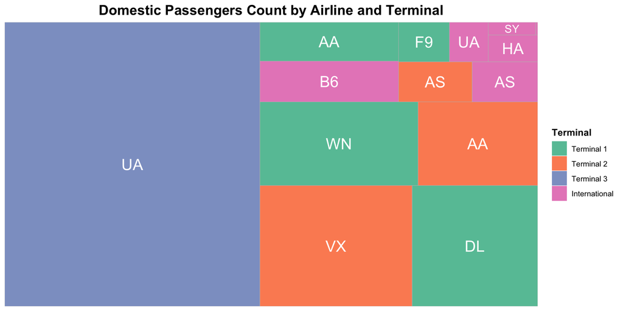

```r
data %>%
  filter(isDomestic, !is.na(code) & year == 2017) %>%
  group_by(terminal, airline, code) %>%
  summarise(all_pax = sum(pax)) %>%
  ggplot(aes(area = all_pax, fill = terminal, label = code, group = airline)) +
  geom_treemap() +
  geom_treemap_text(colour = "white", place = "centre") +
  scale_fill_brewer(name = "Terminal", palette = "Set2") +
  ggtitle("Domestic Passengers Count by Airline and Terminal") +
  format_title +
  format_legend_title
```

```r
pax_terminal <- data %>% filter(isDomestic & year == 2017 & terminal != "other") %>%
                  group_by(terminal) %>%
                  summarise(sumpax = sum(pax)) %>%
                  mutate(prct_pax = sumpax/sum(sumpax)) %>%
                  arrange(desc(prct_pax))
```

As we can see from the tree map: `United Airlines` is assigned to dock at T3, although some `United Airlines` flights dock at IT. `Delta Airlines`, `Southwest Airlines`, `Frontier Airlines` and some `American Airlines` flights were assigned T1. T2 serves the flights of `Alaska Airlines`, `Virgin Airlines`, and the remaining `American Airlines` flights. Due to the limited capacity of T1, T2, T3, the remaining domestic carriers with less flight frequency from/to SFO, including `Hawaiian Airlines`, `Jetblue Airways`, `Sun Country Airlines`, and some `Alaska Airlines` flights, are forced to dock at IT even though they are domestic flights.

About `47.88%` passengers traveled via Terminal 3 in 2017, which makes Terminal 3 the busiest terminal in SFO, followed by Terminal 1 with `23.64%` of the domestic passengers. The remaining domestic passenger traveled in Terminal 2 and International contributed `20.7%` and `7.77%` to the domestic passenger traffic, respectively.

Almost half of the domestic passengers in 2017 traveled with `United Airlines` which makes up the largest share of the domestic flight market, followed by the major domestic airlines includes `American Airlines`, `Alaska Airlines`, `Delta Airlines`, `Virgin America`, and the low cost carrier giant `Southwest Airlines`.

### VI. Airlines

`United Airlines` is the largest carrier in SFO in terms of passengers traffic in 2017, both in domestic or international flights. Since `United Airlines` designates SFO as one of their hubs, `United Airlines` has assigned a lot of flights fly in and out from SFO. In `United Airlines`’ perspective, SFO is the 5th largest hub measured by number of flights, and the primary hub on the West Coast.

`United Airlines`’ footstep in SFO can be traced back in 1937, `United Airlines` operated scheduled service between Los Angeles and New York in January 1937 after it was formed in 1934. Also, `United Airlines` has one of the largest single aircraft maintenance bases in SFO.

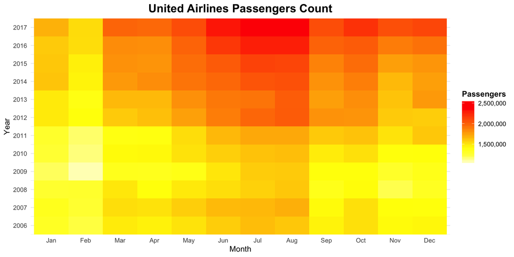

```r
data %>%
  filter(code == "UA") %>%
  group_by(month, year) %>%
  summarise(Passengers = sum(pax)) %>%
  ggplot(aes(x = factor(month, labels = month.abb), y = year)) +
  geom_tile(aes(fill = Passengers)) +
  scale_x_discrete(name = "Month") +
  scale_y_continuous(expand = c(0, 0),
    name = "Year", breaks = seq(min(data$year), max(data$year), by = 1)) +
  scale_fill_gradientn(colours = rev(heat.colors(10)), labels = comma) +
  theme_minimal() +
  ggtitle("United Airlines Passengers Count") +
  format_title +
  format_legend_title
```

The above heat map shows that the passenger traffic was relatively low by 2012. The passenger traffic jumped after 2012 and continued to grow. Also, we can confirm that there were more passengers travel by `United Airlines` in summer period as `June`, `July`, and `August` of every year tend to have a darker colored pattern compare to the months of the same years, which means `United Airlines`’ operation was very sensitive to seasonal effect.

## Part 4: Conclusions and Future Analysis

However, the dataset we have for this report focus mainly on the passenger counts of region the flights fly to or from, there is no information on destination/origin cities and country, aircraft models. In this report, we are not able to trace any of destination/origin cities and country of the airlines. In the future, we would like to explore more on destination/origin cities and country and aircraft models each flight. Additionally, we are surprised on the passenger traffic of `United Airlines` continue to grow although the `United Airlines`’ reputation worsened in recent years. We would like to observe the passenger traffic change on `United Airlines` in the next few years if the reputation effect occurs.